# Project:

Combined bubble plot looks a bit messy, so I've desided to plot the GDP levels contries separately. This is GDP level 2

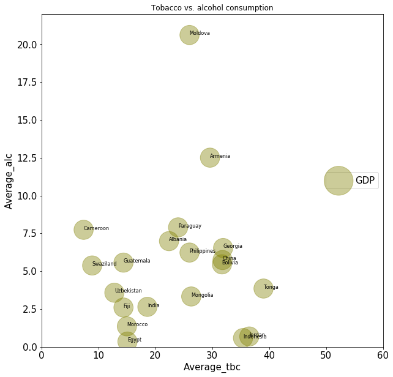

```python
# Creates a scatter plot that uses GDP levels to set colors and bubble sizes
ax=cond2 \
.plot.scatter(x='Average_tbc',y= 'Average_alc',c=ca2,s = cond2['Average_gdp']*500,\
alpha=0.4,figsize=(10,10),fontsize=15,label ='GDP',title='Tobacco vs. alcohol consumption')

## Creates annotation for each contry
for i, txt in enumerate(cond2.cntry):
    ax.annotate(txt, (cond2['Average_tbc'].iat[i],cond2['Average_alc'].iat[i]),fontsize=8 )

# Creates legend
ax.legend(scatterpoints=1,loc='right',ncol=1,markerscale=1.5,fontsize=15)

#Sets x and y axes labels
ax.set_xlabel('Average_tbc',fontsize = 15) #xlabel
ax.set_ylabel('Average_alc', fontsize = 15)#ylabel

#Sets x and y axes limits
ax.set_ylim(0,22)
ax.set_xlim(0,60);
```

This is the same part of the main bubble plot and answer the same questions so please refer to reasoning and explanation to paragraph with the combined bubble plot.

Combined bubble plot looks a bit messy, so I've desided to plot the GDP levels contries separately. This is GDP level 3

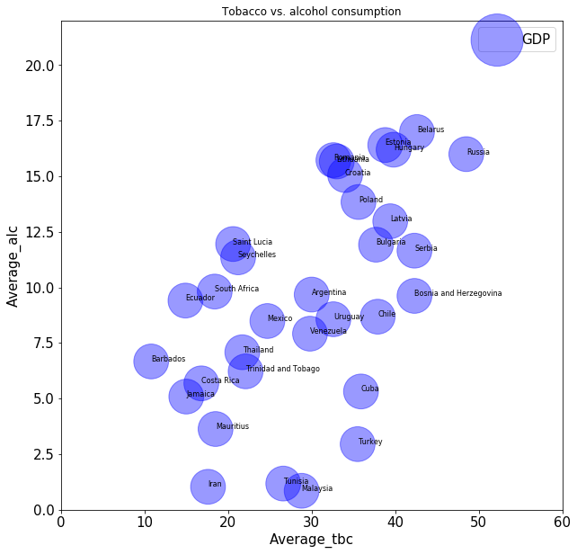

```python
# Creates a scatter plot that uses GDP levels to set colors and bubble sizes
ax=cond3 \
.plot.scatter(x='Average_tbc',y= 'Average_alc',c=ca3,s = cond3['Average_gdp']*500,\
alpha=0.4,figsize=(10,10),fontsize=15,label ='GDP',title='Tobacco vs. alcohol consumption')

## Creates annotation for each contry
for i, txt in enumerate(cond3.cntry):
    ax.annotate(txt, (cond3['Average_tbc'].iat[i],cond3['Average_alc'].iat[i]),fontsize=8 )

# Creates legend
ax.legend(scatterpoints=1,loc='best',ncol=1,markerscale=1.5,fontsize=15)

#Sets x and y axes labels
ax.set_xlabel('Average_tbc',fontsize = 15) #xlabel
ax.set_ylabel('Average_alc', fontsize = 15)#ylabel

#Sets x and y axes limits
ax.set_ylim(0,22)
ax.set_xlim(0,60);
```

This is the same part of the main bubble plot and answer the same questions so please refer to reasoning and explanation to paragraph with the combined bubble plot.

Combined bubble plot looks a bit messy, so I've desided to plot the GDP levels contries separately. This is GDP level 4

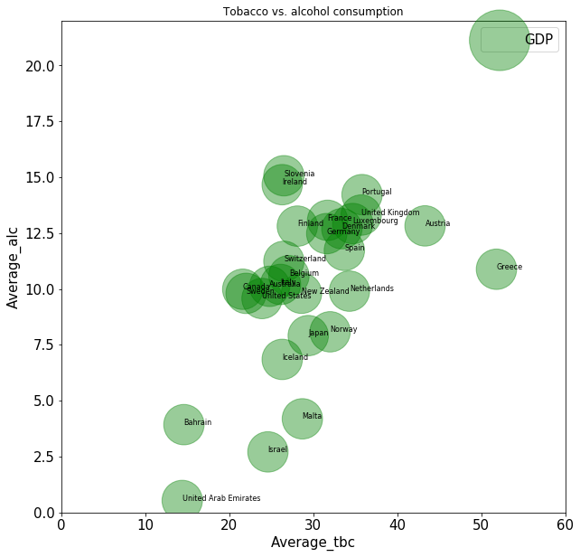

```python
# Creates a scatter plot that uses GDP levels to set colors and bubble sizes
ax=cond4 \
.plot.scatter(x='Average_tbc',y= 'Average_alc',c=ca4,s = cond4['Average_gdp']*500,\
alpha=0.4,figsize=(10,10),fontsize=15,label ='GDP',title='Tobacco vs. alcohol consumption')

## Creates annotation for each contry
for i, txt in enumerate(cond4.cntry):
    ax.annotate(txt, (cond4['Average_tbc'].iat[i],cond4['Average_alc'].iat[i]),fontsize=8 )

# Creates legend
ax.legend(scatterpoints=1,loc='best',ncol=1,markerscale=1.5,fontsize=15)

#Sets x and y axes labels
ax.set_xlabel('Average_tbc',fontsize = 15) #xlabel
ax.set_ylabel('Average_alc', fontsize = 15)#ylabel

#Sets x and y axes limits
ax.set_ylim(0,22)
ax.set_xlim(0,60);
```

This is the same part of the main bubble plot and answer the same questions so please refer to reasoning and explanation to paragraph with the combined bubble plot.

## Conclusions

### 1) What countries that have the lowest/highest GDP have lowest/highest average fertility level? How does it correspond to acohol or tobacco consumption data? Is this affected by GDP?

- The lowest GDP county with highest fertility - Uganda and lowest fertility is in Kyrgystan.
- The highest GDP contry with highest fertility - Israel and lowest fertility are Slovenia, Italy and Spain
- The data investigation revieled that the most tobacco and alcohol consumption is concentrated in contries with the higher income (levels 2,3 and 4). In addition these contries tend to have lower fertility levels.

### 2) What countries that have the lowest/highest GDP have lowest/highest car crash statistics? How does it correspond to acohol or tobacco consumption data? Is this affected by GDP?

- The lowest GDP county with highest car mortality - Comoros and lowest car mortality is in Combodia.
- The highest GDP contry with highest car mortality - United Arab Emirates and lowest car mortality is in Malta
- The data investigation revieled that the most tobacco and alcohol consumption is concentrated in contries with the higher income (levels 2,3 and 4). The most car mortality levels seem to be also spread across these contries .

### Potential drawbacks and improvements

- As was stated earlier all the N/A value were droped to make the data list as consistent as possible, though these values impose significant gap in the reserch data that can be adjusted with more data available. The potential improvement could be filling the missing data at least with average values without the time frame.
- The implementation of code in this report could be improved by inserting a function that will increase the speed of the bubble plot creation and reduce repetative code.
- Analysis provided in this report could be easily questioned due to abscense of most of the data (as we had more then 200 contries and ended up with only 95 for four indicators. The car crash data even had less reading available, that were spread accross the data set.
- The conclusions could be pumped up by inserting a descriptive statistical analysis. Calculating the Gaussian distribution tails could give more presize data on the end points.

### References:

- Gapminder;
- Pandas documentation;
- Numpy documentation;
- Matplotlib documentation;
- Stack Overflow.

```python
from subprocess import call
call(['python', '-m', 'nbconvert', 'Investigate_a_Dataset.ipynb'])
```

```
0
```